# Matrix Representation of Texts

## Part 1: Minimal Text Matrices (Counts and TF-IDF)

This notebook builds a tiny synthetic text dataset and shows how text can be represented as matrices.

```r
library(tidyverse)
library(tidytext)
library(knitr)
```

### 1) Create a minimal tidy text dataframe

`df_texts` contains a document index and three short synthetic headlines. Some words recur across documents so we can later see how TF-IDF differs from raw counts.

```r
df_texts <- tibble(
  doc_id = paste0("doc_", 1:3),
  headline = c(
    "City council approves new park plan",
    "New park plan faces budget debate",
    "Budget debate grows as city park opens"
  )
)

df_texts
```

```
## # A tibble: 3 × 2
##   doc_id headline
##   <chr>  <chr>
## 1 doc_1  City council approves new park plan
## 2 doc_2  New park plan faces budget debate
## 3 doc_3  Budget debate grows as city park opens
```

### 2) Tokenize into `df_tokens`

We split each headline into word tokens. This is the standard tidy representation: one row per token occurrence.

```r
df_tokens <- df_texts %>%
  unnest_tokens(output = token, input = headline)

df_tokens
```

```
## # A tibble: 19 × 2
##    doc_id token
##    <chr>  <chr>
##  1 doc_1  city
##  2 doc_1  council
##  3 doc_1  approves
##  4 doc_1  new
##  5 doc_1  park
##  6 doc_1  plan
##  7 doc_2  new
##  8 doc_2  park
##  9 doc_2  plan
## 10 doc_2  faces
## 11 doc_2  budget
## 12 doc_2  debate
## 13 doc_3  budget
## 14 doc_3  debate
## 15 doc_3  grows
## 16 doc_3  as
## 17 doc_3  city
## 18 doc_3  park
## 19 doc_3  opens
```

### 3) Visualize token frequencies by headline

We count token frequency inside each document and plot horizontal bars.

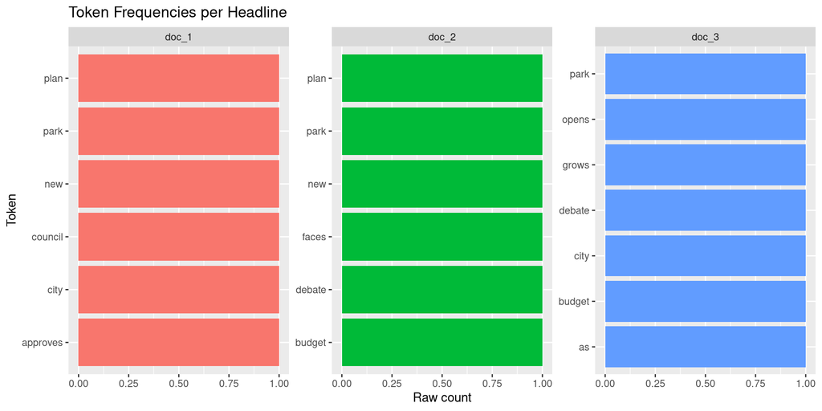

```r
token_freq <- df_tokens %>%
  count(doc_id, token, sort = TRUE)

token_freq %>%
  ggplot(aes(
    x = tidytext::reorder_within(token, n, doc_id),
    y = n,
    fill = doc_id
  )) +
  geom_col(show.legend = FALSE) +
  coord_flip() +
  tidytext::scale_x_reordered() +
  facet_wrap(~doc_id, scales = "free_y") +
  labs(
    title = "Token Frequencies per Headline",
    x = "Token",
    y = "Raw count"
  )
```

### 4) Build a count DTM: `dtm_counts`

A document-term matrix (DTM) stores term frequencies in matrix form. Here we display terms as rows and documents as columns.

```r
df_text <- df_texts

dtm_counts_long <- df_tokens %>%
  count(doc_id, token, name = "count") %>%
  rename(document = doc_id, term = token)

dtm_counts <- dtm_counts_long %>%
  pivot_wider(
    names_from = document,
    values_from = count,
    values_fill = 0
  ) %>%
  arrange(term)

readr::write_tsv(dtm_counts, "df_dtm.tsv")

kable(dtm_counts, caption = "DTM with raw counts (terms as rows, documents as columns)")
```

DTM with raw counts (terms as rows, documents as columns)

| term | doc_1 | doc_2 | doc_3 |
| --- | --- | --- | --- |
| approves | 1 | 0 | 0 |
| as | 0 | 0 | 1 |
| budget | 0 | 1 | 1 |
| city | 1 | 0 | 1 |
| council | 1 | 0 | 0 |
| debate | 0 | 1 | 1 |
| faces | 0 | 1 | 0 |
| grows | 0 | 0 | 1 |
| new | 1 | 1 | 0 |
| opens | 0 | 0 | 1 |
| park | 1 | 1 | 1 |
| plan | 1 | 1 | 0 |

Raw counts are easy to interpret, but common terms can dominate even if they are not distinctive for a specific document.

### 5) Convert counts to TF-IDF: `dtm_tfidf`

We compute:

- `tf` (term frequency): term count divided by total terms in a document.
- `idf` (inverse document frequency): $\log(N / df)$, where `N` is number of documents and `df` is the number of documents containing the term.
- `tf_idf`: `tf * idf`.

So, compared with raw counts, TF-IDF downweights terms that appear in many documents and upweights terms that are more document-specific.

```r
dtm_tfidf_long <- dtm_counts_long %>%
  bind_tf_idf(term = term, document = document, n = count)

kable(
  dtm_tfidf_long %>%
    arrange(document, desc(tf_idf)) %>%
    mutate(across(c(tf, idf, tf_idf), ~round(.x, 3))),
  caption = "Per document-term pair with raw count, tf, idf, and tf-idf"
)
```

Per document-term pair with raw count, tf, idf, and tf-idf

| document | term | count | tf | idf | tf_idf |
| --- | --- | --- | --- | --- | --- |
| doc_1 | approves | 1 | 0.167 | 1.099 | 0.183 |
| doc_1 | council | 1 | 0.167 | 1.099 | 0.183 |
| doc_1 | city | 1 | 0.167 | 0.405 | 0.068 |
| doc_1 | new | 1 | 0.167 | 0.405 | 0.068 |
| doc_1 | plan | 1 | 0.167 | 0.405 | 0.068 |
| doc_1 | park | 1 | 0.167 | 0.000 | 0.000 |
| doc_2 | faces | 1 | 0.167 | 1.099 | 0.183 |
| doc_2 | budget | 1 | 0.167 | 0.405 | 0.068 |
| doc_2 | debate | 1 | 0.167 | 0.405 | 0.068 |
| doc_2 | new | 1 | 0.167 | 0.405 | 0.068 |
| doc_2 | plan | 1 | 0.167 | 0.405 | 0.068 |
| doc_2 | park | 1 | 0.167 | 0.000 | 0.000 |
| doc_3 | as | 1 | 0.143 | 1.099 | 0.157 |
| doc_3 | grows | 1 | 0.143 | 1.099 | 0.157 |
| doc_3 | opens | 1 | 0.143 | 1.099 | 0.157 |
| doc_3 | budget | 1 | 0.143 | 0.405 | 0.058 |
| doc_3 | city | 1 | 0.143 | 0.405 | 0.058 |
| doc_3 | debate | 1 | 0.143 | 0.405 | 0.058 |
| doc_3 | park | 1 | 0.143 | 0.000 | 0.000 |

```r
dtm_tfidf <- dtm_tfidf_long %>%
  select(term, document, tf_idf) %>%
  pivot_wider(
    names_from = document,
    values_from = tf_idf,
    values_fill = 0
  ) %>%
  arrange(term)

kable(
  dtm_tfidf %>% mutate(across(-term, ~round(.x, 3))),
  caption = "TF-IDF matrix (terms as rows, documents as columns)"
)
```

TF-IDF matrix (terms as rows, documents as columns)

| term | doc_1 | doc_2 | doc_3 |
| --- | --- | --- | --- |
| approves | 0.183 | 0.000 | 0.000 |
| as | 0.000 | 0.000 | 0.157 |
| budget | 0.000 | 0.068 | 0.058 |
| city | 0.068 | 0.000 | 0.058 |
| council | 0.183 | 0.000 | 0.000 |
| debate | 0.000 | 0.068 | 0.058 |
| faces | 0.000 | 0.183 | 0.000 |
| grows | 0.000 | 0.000 | 0.157 |
| new | 0.068 | 0.068 | 0.000 |
| opens | 0.000 | 0.000 | 0.157 |
| park | 0.000 | 0.000 | 0.000 |
| plan | 0.068 | 0.068 | 0.000 |

### 6) Quick comparison: raw counts vs TF-IDF

This table shows how the same term-document entries look under raw frequency and TF-IDF weighting.

```r
comparison <- dtm_tfidf_long %>%
  select(document, term, raw_count = count, tf, idf, tf_idf) %>%
  arrange(term, document) %>%
  mutate(across(c(tf, idf, tf_idf), ~round(.x, 3)))

kable(comparison, caption = "Raw count vs TF-IDF components")
```

Raw count vs TF-IDF components

| document | term | raw_count | tf | idf | tf_idf |
| --- | --- | --- | --- | --- | --- |
| doc_1 | approves | 1 | 0.167 | 1.099 | 0.183 |
| doc_3 | as | 1 | 0.143 | 1.099 | 0.157 |
| doc_2 | budget | 1 | 0.167 | 0.405 | 0.068 |
| doc_3 | budget | 1 | 0.143 | 0.405 | 0.058 |
| doc_1 | city | 1 | 0.167 | 0.405 | 0.068 |
| doc_3 | city | 1 | 0.143 | 0.405 | 0.058 |
| doc_1 | council | 1 | 0.167 | 1.099 | 0.183 |
| doc_2 | debate | 1 | 0.167 | 0.405 | 0.068 |
| doc_3 | debate | 1 | 0.143 | 0.405 | 0.058 |
| doc_2 | faces | 1 | 0.167 | 1.099 | 0.183 |
| doc_3 | grows | 1 | 0.143 | 1.099 | 0.157 |
| doc_1 | new | 1 | 0.167 | 0.405 | 0.068 |
| doc_2 | new | 1 | 0.167 | 0.405 | 0.068 |
| doc_3 | opens | 1 | 0.143 | 1.099 | 0.157 |
| doc_1 | park | 1 | 0.167 | 0.000 | 0.000 |
| doc_2 | park | 1 | 0.167 | 0.000 | 0.000 |
| doc_3 | park | 1 | 0.143 | 0.000 | 0.000 |
| doc_1 | plan | 1 | 0.167 | 0.405 | 0.068 |
| doc_2 | plan | 1 | 0.167 | 0.405 | 0.068 |

This small example illustrates the core idea: matrix representations of text let us move from simple frequency counts to weighted features that better capture term distinctiveness.

## Part 2: Corpus, DTM/TF-IDF, and 2-Topic LDA

This notebook extends the minimal text example to two contrasting themes and compares matrix representations (raw counts vs TF-IDF) for topic modeling.

```r
knitr::opts_chunk$set(echo = TRUE, message = FALSE, warning = FALSE, error = FALSE)

library(tidyverse)
library(tm)
library(tidytext)
library(topicmodels)
library(slam)
library(knitr)

required_pkgs <- c("tidyverse", "tm", "tidytext", "topicmodels", "slam", "knitr")
missing_pkgs <- required_pkgs[!vapply(required_pkgs, requireNamespace, logical(1), quietly = TRUE)]
if (length(missing_pkgs) > 0) {
  stop(
    paste0("[ISSUE] Missing required packages: ", paste(missing_pkgs, collapse = ", ")),
    call. = FALSE
  )
}

fail_with <- function(step, expr) {
  tryCatch(
    eval.parent(substitute(expr)),
    error = function(e) {
      msg <- paste0("[ISSUE] ", step, " failed: ", conditionMessage(e))
      message(msg)
      stop(msg, call. = FALSE)
    }
  )
}
```

### 1) Extend `df_texts` with a contrasting topic

The first three headlines are civic policy, and the next three are tech/business. Some words repeat within and across headlines (for example: `new`, `debate`, `ai`, and repeated `debate` inside one headline).

```r
df_texts <- fail_with("Creating df_texts", {
  tibble(
    doc_id = paste0("doc_", 1:6),
    theme = c(rep("civic", 3), rep("tech", 3)),
    headline = c(
      "City council approves new park plan",
      "New park plan faces budget debate",
      "Budget debate grows as city park opens",
      "Tech firms race to launch new AI phone",
      "New AI phone sparks privacy debate debate",
      "Market analysts say tech stocks rise on AI"
    )
  )
})

df_texts
```

```
## # A tibble: 6 × 3
##   doc_id theme headline
##   <chr>  <chr> <chr>
## 1 doc_1  civic City council approves new park plan
## 2 doc_2  civic New park plan faces budget debate
## 3 doc_3  civic Budget debate grows as city park opens
## 4 doc_4  tech  Tech firms race to launch new AI phone
## 5 doc_5  tech  New AI phone sparks privacy debate debate
## 6 doc_6  tech  Market analysts say tech stocks rise on AI
```

### 2) Read `df_texts` into a corpus and display corpus properties

```r
corpus <- fail_with("Creating corpus from df_texts", {
  corp <- VCorpus(VectorSource(df_texts$headline))
  names(corp) <- df_texts$doc_id
  corp
})

corpus_properties <- tibble(
  property = c("class", "documents", "total_characters", "average_characters"),
  value = c(
    class(corpus)[1],
    length(corpus),
    sum(nchar(vapply(corpus, content, FUN.VALUE = character(1)))),
    round(mean(nchar(vapply(corpus, content, FUN.VALUE = character(1)))), 1)
  )
)

corpus_docs <- tibble(
  doc_id = names(corpus),
  headline = vapply(corpus, content, FUN.VALUE = character(1)),
  n_words = stringr::str_count(vapply(corpus, content, FUN.VALUE = character(1)), "\\S+")
) %>%
  left_join(df_texts %>% select(doc_id, theme), by = "doc_id")

kable(corpus_properties, caption = "Corpus-level properties")
```

Corpus-level properties

| property | value |
| --- | --- |
| class | VCorpus |
| documents | 6 |
| total_characters | 227 |
| average_characters | 37.8 |

```r
kable(corpus_docs, caption = "Document-level corpus summary")
```

Document-level corpus summary

| doc_id | headline | n_words | theme |
| --- | --- | --- | --- |
| doc_1 | City council approves new park plan | 6 | civic |
| doc_2 | New park plan faces budget debate | 6 | civic |
| doc_3 | Budget debate grows as city park opens | 7 | civic |
| doc_4 | Tech firms race to launch new AI phone | 8 | tech |
| doc_5 | New AI phone sparks privacy debate debate | 7 | tech |
| doc_6 | Market analysts say tech stocks rise on AI | 8 | tech |

### 3) Cast corpus to raw count DTM and TF-IDF object

```r
corpus_clean <- fail_with("Cleaning corpus text", {
  corpus %>%
    tm_map(content_transformer(tolower)) %>%
    tm_map(removePunctuation) %>%
    tm_map(removeNumbers) %>%
    tm_map(removeWords, stopwords("en")) %>%
    tm_map(stripWhitespace)
})

dtm_counts <- fail_with("Casting corpus to raw-count DTM", {
  DocumentTermMatrix(corpus_clean, control = list(wordLengths = c(2, Inf)))
})

dtm_tfidf <- fail_with("Computing TF-IDF DTM", {
  weightTfIdf(dtm_counts, normalize = TRUE)
})

dtm_properties <- function(x, object_name) {
  d <- dim(x)
  non_zero <- length(x$v)
  tibble(
    object = object_name,
    class = class(x)[1],
    documents = d[1],
    terms = d[2],
    non_zero_cells = non_zero,
    sparsity = round(1 - non_zero / (d[1] * d[2]), 3),
    weighting = paste(attr(x, "weighting"), collapse = " / ")
  )
}

obj_props <- bind_rows(
  dtm_properties(dtm_counts, "dtm_counts"),
  dtm_properties(dtm_tfidf, "dtm_tfidf")
)

kable(obj_props, caption = "DTM object properties")
```

DTM object properties

| object | class | documents | terms | non_zero_cells | sparsity | weighting |
| --- | --- | --- | --- | --- | --- | --- |
| dtm_counts | DocumentTermMatrix | 6 | 24 | 38 | 0.736 | term frequency / tf |
| dtm_tfidf | DocumentTermMatrix | 6 | 24 | 38 | 0.736 | term frequency - inverse document frequency (normalized) / tf-idf |

```r
counts_preview <- tidy(dtm_counts) %>%
  arrange(document, desc(count))

tfidf_preview <- tidy(dtm_tfidf) %>%
  arrange(document, desc(count))

kable(head(counts_preview, 18), caption = "Raw count DTM (long format preview)")
```

Raw count DTM (long format preview)

| document | term | count |
| --- | --- | --- |
| doc_1 | approves | 1 |
| doc_1 | city | 1 |
| doc_1 | council | 1 |
| doc_1 | new | 1 |
| doc_1 | park | 1 |
| doc_1 | plan | 1 |
| doc_2 | budget | 1 |
| doc_2 | debate | 1 |
| doc_2 | faces | 1 |
| doc_2 | new | 1 |
| doc_2 | park | 1 |
| doc_2 | plan | 1 |
| doc_3 | budget | 1 |
| doc_3 | city | 1 |
| doc_3 | debate | 1 |
| doc_3 | grows | 1 |
| doc_3 | opens | 1 |
| doc_3 | park | 1 |

```r
kable(head(tfidf_preview, 18), caption = "TF-IDF DTM (long format preview)")
```

TF-IDF DTM (long format preview)

| document | term | count |
| --- | --- | --- |
| doc_1 | approves | 0.4308271 |
| doc_1 | council | 0.4308271 |
| doc_1 | city | 0.2641604 |
| doc_1 | plan | 0.2641604 |
| doc_1 | park | 0.1666667 |
| doc_1 | new | 0.0974938 |
| doc_2 | faces | 0.4308271 |
| doc_2 | budget | 0.2641604 |
| doc_2 | plan | 0.2641604 |
| doc_2 | debate | 0.1666667 |
| doc_2 | park | 0.1666667 |
| doc_2 | new | 0.0974938 |
| doc_3 | grows | 0.4308271 |
| doc_3 | opens | 0.4308271 |
| doc_3 | budget | 0.2641604 |
| doc_3 | city | 0.2641604 |
| doc_3 | debate | 0.1666667 |
| doc_3 | park | 0.1666667 |

### 4) Fit LDA with `k = 2` on raw counts and TF-IDF representations

`topicmodels::LDA()` requires term-frequency weighted input. Raw counts already satisfy this. For TF-IDF, we rescale TF-IDF weights to non-negative pseudo-count integers and cast back to a term-frequency DTM for a comparable 2-topic run.

```r
set.seed(2026)

lda_counts <- fail_with("Fitting LDA on dtm_counts", {
  LDA(
    dtm_counts,
    k = 2,
    method = "Gibbs",
    control = list(seed = 2026, burnin = 500, iter = 2000, thin = 100)
  )
})

dtm_tfidf_for_lda <- fail_with("Preparing TF-IDF representation for LDA", {
  tfidf_mat <- as.matrix(dtm_tfidf)
  if (!is.numeric(tfidf_mat)) stop("TF-IDF matrix is not numeric")
  if (any(tfidf_mat < 0)) stop("TF-IDF matrix contains negative values")

  scale_factor <- 1000
  tfidf_scaled <- round(tfidf_mat * scale_factor)

  if (all(tfidf_scaled == 0)) {
    stop("Scaled TF-IDF matrix is all zeros; cannot fit LDA")
  }

  as.DocumentTermMatrix(
    slam::as.simple_triplet_matrix(tfidf_scaled),
    weighting = weightTf
  )
})

lda_tfidf <- fail_with("Fitting LDA on TF-IDF-based representation", {
  LDA(
    dtm_tfidf_for_lda,
    k = 2,
    method = "Gibbs",
    control = list(seed = 2026, burnin = 500, iter = 2000, thin = 100)
  )
})
```

### 5) Visualize how terms contribute to topics

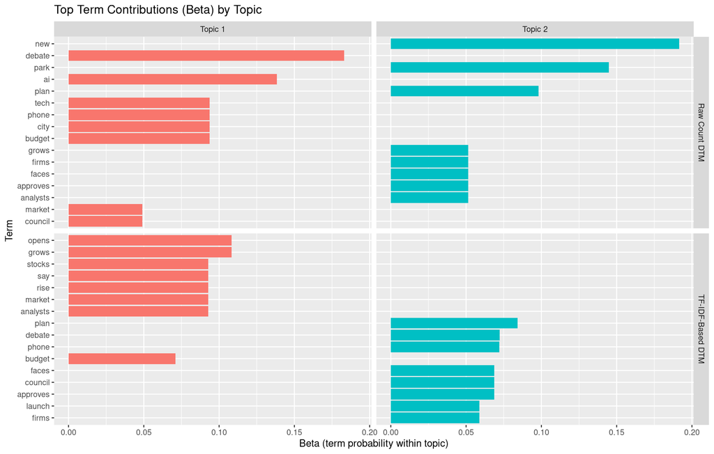

```r
extract_top_terms <- function(model, model_name, top_n = 8) {
  tidy(model, matrix = "beta") %>%
    group_by(topic) %>%
    slice_max(order_by = beta, n = top_n, with_ties = FALSE) %>%
    ungroup() %>%
    mutate(
      model = model_name,
      topic = paste0("Topic ", topic)
    )
}

beta_terms <- bind_rows(
  extract_top_terms(lda_counts, "Raw Count DTM"),
  extract_top_terms(lda_tfidf, "TF-IDF-Based DTM")
) %>%
  mutate(term_plot = reorder_within(term, beta, interaction(model, topic)))

beta_terms %>%
  ggplot(aes(x = term_plot, y = beta, fill = topic)) +
  geom_col(show.legend = FALSE) +
  coord_flip() +
  tidytext::scale_x_reordered() +
  facet_grid(model ~ topic, scales = "free_y") +
  labs(
    title = "Top Term Contributions (Beta) by Topic",
    x = "Term",
    y = "Beta (term probability within topic)"
  )
```

### 6) Visualize how headlines connect to topics

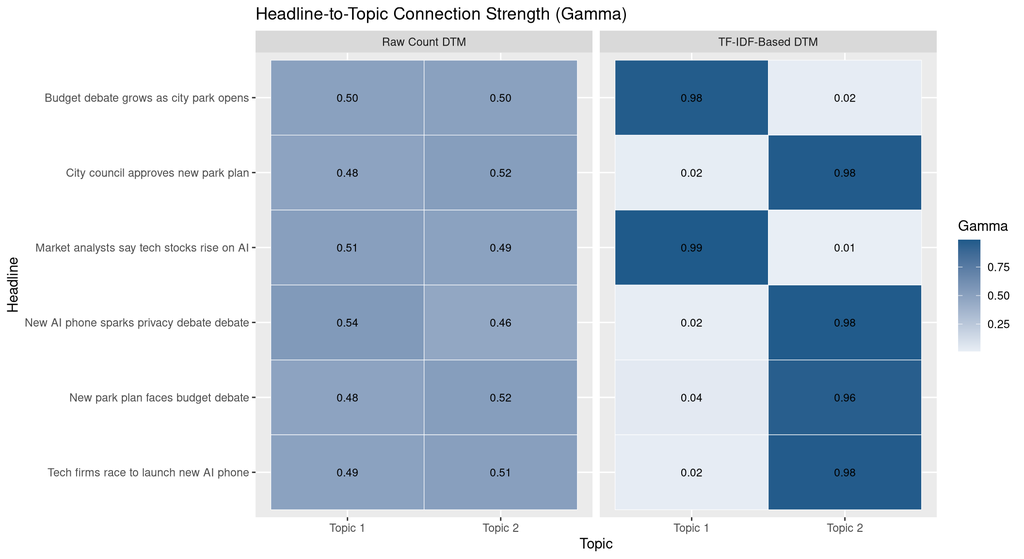

```r
extract_doc_topics <- function(model, model_name) {
  tidy(model, matrix = "gamma") %>%
    mutate(model = model_name, topic = paste0("Topic ", topic))
}

doc_topics <- bind_rows(
  extract_doc_topics(lda_counts, "Raw Count DTM"),
  extract_doc_topics(lda_tfidf, "TF-IDF-Based DTM")
) %>%
  mutate(document = as.character(document)) %>%
  left_join(df_texts, by = c("document" = "doc_id")) %>%
  mutate(headline_short = stringr::str_trunc(headline, 42))

if (any(is.na(doc_topics$headline_short))) {
  stop("[ISSUE] Could not join topic assignments back to headlines", call. = FALSE)
}

doc_topics %>%
  ggplot(aes(x = topic, y = forcats::fct_rev(headline_short), fill = gamma)) +
  geom_tile(color = "white") +
  geom_text(aes(label = sprintf("%.2f", gamma)), size = 3) +
  facet_wrap(~model) +
  scale_fill_gradient(low = "#e8eef5", high = "#1f5a8a") +
  labs(
    title = "Headline-to-Topic Connection Strength (Gamma)",
    x = "Topic",
    y = "Headline",
    fill = "Gamma"
  )
```

This notebook emphasizes matrix representations of minimal text data and how weighting choices (raw counts vs TF-IDF-based representation) affect topic interpretation.

## Part 4: Corpus DTM and LDA Topic Tuning (text-data/*.txt)

This notebook reads all `.txt` files in `text-data/` into a corpus, builds a count-based document-term matrix (DTM), tunes LDA topic count (`k = 1..10`) using coherence and confusion diagnostics, selects an optimal `k`, and interprets the best model.

```r
knitr::opts_chunk$set(echo = TRUE, message = FALSE, warning = FALSE, error = FALSE)

library(tidyverse)
library(tm)
library(topicmodels)
library(tidytext)
library(readr)
library(knitr)

required_pkgs <- c("tidyverse", "tm", "topicmodels", "tidytext", "readr", "knitr")
missing_pkgs <- required_pkgs[!vapply(required_pkgs, requireNamespace, logical(1), quietly = TRUE)]
if (length(missing_pkgs) > 0) {
  stop(
    paste0("[ISSUE] Missing required packages: ", paste(missing_pkgs, collapse = ", ")),
    call. = FALSE
  )
}
```

### 1) Read all text files to `df_texts` and a corpus object

```r
text_files <- sort(list.files("text-data", pattern = "\\.txt$", full.names = TRUE))
if (length(text_files) == 0) {
  stop("[ISSUE] No .txt files found in text-data/", call. = FALSE)
}

df_texts <- tibble(
  doc_id = basename(text_files),
  text = vapply(text_files, readr::read_file, FUN.VALUE = character(1))
)

corpus <- VCorpus(VectorSource(df_texts$text))
names(corpus) <- df_texts$doc_id

corpus_props <- tibble(
  property = c("documents", "total_characters", "avg_characters", "total_words", "avg_words"),
  value = c(
    length(corpus),
    sum(nchar(df_texts$text)),
    round(mean(nchar(df_texts$text)), 1),
    sum(stringr::str_count(df_texts$text, "\\S+")),
    round(mean(stringr::str_count(df_texts$text, "\\S+")), 1)
  )
)

corpus_preview <- df_texts %>%
  transmute(
    doc_id,
    text_preview = stringr::str_trunc(stringr::str_squish(text), 140)
  )

kable(corpus_props, caption = "Corpus properties")
```

Corpus properties

| property | value |
| --- | --- |
| documents | 9.0 |
| total_characters | 79033.0 |
| avg_characters | 8781.4 |
| total_words | 11441.0 |
| avg_words | 1271.2 |

```r
kable(corpus_preview, caption = "Document previews")
```

Document previews

| doc_id | text_preview |
| --- | --- |
| equinor01-protecting-the-environment.txt | Protecting the environment Home>Sustainability>Protecting the environment Being a large offshore oil and gas operator and a growing offsh… |
| equinor02-health-safety-and-security.txt | Health, safety and security Home>Sustainability>Health, safety and security Safety: Our vision is zero harm The safety and security of ou… |
| equinor03-human-rights.txt | Home>Sustainability>Human rights Human rights Our policy Our priority areasOur approach to due diligenceSearch ENNO Menu ReportingThe Nor… |
| equinor04-governance-and-transparency.txt | Governance and transparency Home>Sustainability>Governance and transparency Embedding sustainability in governance and risk management At… |
| equinor05-our-transition-ambitions.txt | Home>Sustainability>Energy transition plan Energy Transition PlanSearch ENNO Menu Plan & strategy Ambitions People & nature Downloads Our… |
| equinor06-a-just-energy-transition.txt | Photo: Einar Aslaksen Home>Sustainability>Just transition Equinor’s commitment to a just energy transition As part of the company’s strat… |
| equinor07-environmental-social-and-governance-esg-reporting-centre.txt | Environmental, social and governance (ESG) reporting centre Home>Sustainability>Reporting The reporting centre brings together our key re… |
| equinor08-impact-assessments.txt | Impact assessments Home>Sustainability>Impact assessments A-C D-G H-J K-L M-N O-S T-U V-Å The impact assessment process is an integral pa… |
| equinor09-energy-perspectives.txt | Home>Sustainability>Energy Perspectives Energy Perspectives 2025 Global macroeconomic and energy market outlook About this report: Energy… |

Interpretation: this corpus contains multiple ESG-related documents with substantial shared vocabulary, which is suitable for topic modeling.

### 2) Cast corpus to count DTM

```r
corpus_clean <- corpus %>%
  tm_map(content_transformer(tolower)) %>%
  tm_map(removePunctuation) %>%
  tm_map(removeNumbers) %>%
  tm_map(removeWords, stopwords("en")) %>%
  tm_map(stripWhitespace)

dtm_counts <- DocumentTermMatrix(
  corpus_clean,
  control = list(
    wordLengths = c(3, Inf),
    bounds = list(global = c(2, Inf))
  )
)

non_empty_docs <- slam::row_sums(dtm_counts) > 0
if (!all(non_empty_docs)) {
  removed_docs <- Docs(dtm_counts)[!non_empty_docs]
  message("[ISSUE] Removing empty documents after preprocessing: ", paste(removed_docs, collapse = ", "))
  dtm_counts <- dtm_counts[non_empty_docs, ]
}

if (nrow(dtm_counts) < 2 || ncol(dtm_counts) < 10) {
  stop(
    paste0(
      "[ISSUE] DTM too small for requested topic sweep. Dims = ",
      nrow(dtm_counts), " docs x ", ncol(dtm_counts), " terms"
    ),
    call. = FALSE
  )
}

dtm_props <- tibble(
  property = c("documents", "terms", "non_zero_cells", "sparsity"),
  value = c(
    nrow(dtm_counts),
    ncol(dtm_counts),
    length(dtm_counts$v),
    round(1 - length(dtm_counts$v) / (nrow(dtm_counts) * ncol(dtm_counts)), 3)
  )
)

term_totals <- tidy(dtm_counts) %>%
  group_by(term) %>%
  summarise(total_count = sum(count), .groups = "drop") %>%
  arrange(desc(total_count)) %>%
  slice_head(n = 15)

kable(dtm_props, caption = "Count DTM properties")
```

Count DTM properties

| property | value |
| --- | --- |
| documents | 9.000 |
| terms | 618.000 |
| non_zero_cells | 1887.000 |
| sparsity | 0.661 |

```r
kable(term_totals, caption = "Most frequent terms in the count DTM")
```

Most frequent terms in the count DTM

| term | total_count |
| --- | --- |
| enno | 101 |
| energy | 93 |
| equinor | 59 |
| environmental | 49 |
| impact | 47 |
| transition | 46 |
| report | 42 |
| rights | 39 |
| security | 38 |
| human | 37 |
| management | 36 |
| policy | 36 |
| business | 35 |
| will | 34 |
| gas | 33 |

Interpretation: the DTM is sparse (as expected) but still dense enough in shared terms to support multi-topic modeling.

### 3) Tune LDA over `k = 1..10` with coherence and confusion diagnostics

- **Coherence (UMass)**: higher is better (less negative means better semantic co-occurrence among top topic terms).
- **Topic confusion**: average cosine similarity among topic-term distributions. Lower is better because topics are more distinct.

```r
compute_umass_coherence <- function(model, dtm_binary, top_n = 10) {
  beta <- posterior(model)$terms
  top_n <- min(top_n, ncol(beta))

  topic_scores <- apply(beta, 1, function(topic_probs) {
    top_terms <- names(sort(topic_probs, decreasing = TRUE))[1:top_n]
    if (length(top_terms) < 2) return(NA_real_)

    pairs <- combn(top_terms, 2, simplify = FALSE)
    pair_scores <- map_dbl(pairs, function(p) {
      wi <- p[1]
      wj <- p[2]
      d_wj <- sum(dtm_binary[, wj] > 0)
      d_wi_wj <- sum(dtm_binary[, wi] > 0 & dtm_binary[, wj] > 0)
      log((d_wi_wj + 1) / d_wj)
    })

    mean(pair_scores)
  })

  mean(topic_scores, na.rm = TRUE)
}

compute_topic_confusion <- function(model) {
  beta <- posterior(model)$terms
  k <- nrow(beta)
  if (k < 2) return(NA_real_)

  sims <- c()
  for (i in seq_len(k - 1)) {
    for (j in (i + 1):k) {
      num <- sum(beta[i, ] * beta[j, ])
      den <- sqrt(sum(beta[i, ]^2)) * sqrt(sum(beta[j, ]^2))
      sims <- c(sims, ifelse(den == 0, NA_real_, num / den))
    }
  }

  mean(sims, na.rm = TRUE)
}

normalize_metric <- function(x, higher_is_better = TRUE) {
  rng <- range(x, na.rm = TRUE)
  if (!all(is.finite(rng)) || diff(rng) == 0) {
    return(rep(0.5, length(x)))
  }
  scaled <- (x - rng[1]) / diff(rng)
  if (higher_is_better) scaled else 1 - scaled
}

k_grid <- 1:10
lda_models <- setNames(vector("list", length(k_grid)), as.character(k_grid))

dtm_binary <- as.matrix(dtm_counts)
dtm_binary[dtm_binary > 0] <- 1

tuning_results <- map_dfr(k_grid, function(k) {
  fit <- tryCatch(
    LDA(
      dtm_counts,
      k = k,
      method = "Gibbs",
      control = list(seed = 2026, burnin = 200, iter = 800, thin = 50)
    ),
    error = function(e) e
  )

  if (inherits(fit, "error")) {
    tibble(
      k = k,
      coherence = NA_real_,
      confusion = NA_real_,
      issue = conditionMessage(fit)
    )
  } else {
    lda_models[[as.character(k)]] <<- fit
    tibble(
      k = k,
      coherence = compute_umass_coherence(fit, dtm_binary, top_n = 10),
      confusion = compute_topic_confusion(fit),
      issue = NA_character_
    )
  }
})

unexpected_issues <- tuning_results %>% filter(!is.na(issue), k != 1)
if (nrow(unexpected_issues) > 0) {
  stop(
    paste0(
      "[ISSUE] LDA failed for unexpected k values: ",
      paste0(unexpected_issues$k, collapse = ", ")
    ),
    call. = FALSE
  )
}

valid_rows <- tuning_results %>% filter(is.na(issue), !is.na(coherence), !is.na(confusion))
if (nrow(valid_rows) == 0) {
  stop("[ISSUE] No valid LDA models were fitted for k = 2..10", call. = FALSE)
}

tuning_results <- tuning_results %>%
  mutate(
    coherence_norm = NA_real_,
    confusion_norm = NA_real_,
    combined_score = NA_real_
  )

idx <- which(is.na(tuning_results$issue) & !is.na(tuning_results$coherence) & !is.na(tuning_results$confusion))

coh_norm <- normalize_metric(tuning_results$coherence[idx], higher_is_better = TRUE)
conf_norm <- normalize_metric(tuning_results$confusion[idx], higher_is_better = FALSE)

tuning_results$coherence_norm[idx] <- coh_norm
tuning_results$confusion_norm[idx] <- conf_norm
tuning_results$combined_score[idx] <- (coh_norm + conf_norm) / 2

best_k <- tuning_results %>%
  filter(!is.na(combined_score)) %>%
  arrange(desc(combined_score), desc(coherence), confusion) %>%
  slice(1) %>%
  pull(k)

issue_log <- tuning_results %>%
  filter(!is.na(issue)) %>%
  select(k, issue)

kable(
  tuning_results %>% mutate(across(c(coherence, confusion, combined_score), ~round(.x, 4))),
  caption = "LDA tuning diagnostics for k = 1..10"
)
```

LDA tuning diagnostics for k = 1..10

| k | coherence | confusion | issue | coherence_norm | confusion_norm | combined_score |
| --- | --- | --- | --- | --- | --- | --- |
| 1 | NA | NA | ‘k’ needs to be an integer of at least 2 | NA | NA | NA |
| 2 | -0.1122 | 0.1302 | NA | 0.0000000 | 0.0000000 | 0.0000 |
| 3 | -0.0650 | 0.0566 | NA | 0.5026145 | 1.0000000 | 0.7513 |
| 4 | -0.0182 | 0.0934 | NA | 1.0000000 | 0.4997183 | 0.7499 |
| 5 | -0.0504 | 0.0773 | NA | 0.6578018 | 0.7183724 | 0.6881 |
| 6 | -0.0682 | 0.0787 | NA | 0.4683238 | 0.6997303 | 0.5840 |
| 7 | -0.0433 | 0.0830 | NA | 0.7332594 | 0.6416574 | 0.6875 |
| 8 | -0.0605 | 0.0847 | NA | 0.5498346 | 0.6190702 | 0.5845 |
| 9 | -0.0449 | 0.0792 | NA | 0.7157412 | 0.6936868 | 0.7047 |
| 10 | -0.0574 | 0.0917 | NA | 0.5829343 | 0.5238888 | 0.5534 |

```r
if (nrow(issue_log) > 0) {
  kable(issue_log, caption = "Reported issues during topic sweep")
}
```

Reported issues during topic sweep

| k | issue |
| --- | --- |
| 1 | ‘k’ needs to be an integer of at least 2 |

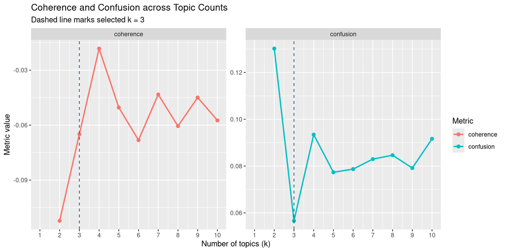

```r
metric_long <- tuning_results %>%
  select(k, coherence, confusion) %>%
  pivot_longer(cols = c(coherence, confusion), names_to = "metric", values_to = "value")

metric_long %>%
  ggplot(aes(x = k, y = value, color = metric)) +
  geom_line(linewidth = 0.9, na.rm = TRUE) +
  geom_point(size = 2, na.rm = TRUE) +
  geom_vline(xintercept = best_k, linetype = "dashed", color = "#1f5a8a") +
  facet_wrap(~metric, scales = "free_y", ncol = 2) +
  scale_x_continuous(breaks = 1:10) +
  labs(
    title = "Coherence and Confusion across Topic Counts",
    subtitle = paste0("Dashed line marks selected k = ", best_k),
    x = "Number of topics (k)",
    y = "Metric value",
    color = "Metric"
  )
```

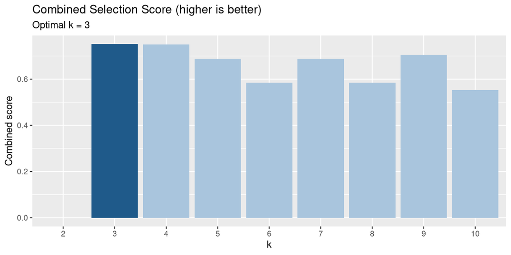

```r
tuning_results %>%
  filter(!is.na(combined_score)) %>%
  ggplot(aes(x = factor(k), y = combined_score, fill = k == best_k)) +
  geom_col(show.legend = FALSE) +
  labs(
    title = "Combined Selection Score (higher is better)",
    subtitle = paste0("Optimal k = ", best_k),
    x = "k",
    y = "Combined score"
  ) +
  scale_fill_manual(values = c("TRUE" = "#1f5a8a", "FALSE" = "#a9c5dd"))
```

Interpretation: based on stronger coherence and lower topic confusion jointly, the selected topic count is **3**.

### 4) Fit/interpret the best topic model

```r
best_model <- lda_models[[as.character(best_k)]]
if (is.null(best_model)) {
  stop(paste0("[ISSUE] Could not retrieve fitted model for best_k = ", best_k), call. = FALSE)
}

doc_lookup <- tibble(
  document = as.character(seq_along(Docs(dtm_counts))),
  doc_id = Docs(dtm_counts)
)

beta_tbl <- tidy(best_model, matrix = "beta")
gamma_tbl <- tidy(best_model, matrix = "gamma") %>%
  mutate(document = as.character(document)) %>%
  left_join(doc_lookup, by = "document") %>%
  mutate(doc_id = if_else(is.na(doc_id), document, doc_id))

if (any(is.na(gamma_tbl$doc_id))) {
  stop("[ISSUE] Failed to map document-topic probabilities to document IDs", call. = FALSE)
}
```

#### Top terms per topic

```r
top_terms_per_topic <- beta_tbl %>%
  group_by(topic) %>%
  slice_max(beta, n = 12, with_ties = FALSE) %>%
  ungroup() %>%
  arrange(topic, desc(beta))

kable(
  top_terms_per_topic %>% mutate(beta = round(beta, 4)),
  caption = paste0("Top terms per topic for k = ", best_k)
)
```

Top terms per topic for k = 3

| topic | term | beta |
| --- | --- | --- |
| 1 | energy | 0.0745 |
| 1 | transition | 0.0369 |
| 1 | will | 0.0273 |
| 1 | equinor | 0.0225 |
| 1 | emissions | 0.0153 |
| 1 | net | 0.0129 |
| 1 | global | 0.0121 |
| 1 | just | 0.0121 |
| 1 | longterm | 0.0121 |
| 1 | zero | 0.0121 |
| 1 | climate | 0.0113 |
| 1 | plan | 0.0113 |
| 2 | enno | 0.0843 |
| 2 | environmental | 0.0410 |
| 2 | impact | 0.0393 |
| 2 | gas | 0.0276 |
| 2 | search | 0.0259 |
| 2 | norwegian | 0.0226 |
| 2 | statement | 0.0226 |
| 2 | offshore | 0.0218 |
| 2 | report | 0.0209 |
| 2 | assessments | 0.0143 |
| 2 | assessment | 0.0134 |
| 2 | oil | 0.0134 |
| 3 | human | 0.0204 |
| 3 | rights | 0.0204 |
| 3 | security | 0.0204 |
| 3 | business | 0.0193 |
| 3 | management | 0.0187 |
| 3 | sustainability | 0.0176 |
| 3 | equinor | 0.0171 |
| 3 | policy | 0.0165 |
| 3 | transparency | 0.0143 |
| 3 | governments | 0.0138 |
| 3 | people | 0.0121 |
| 3 | performance | 0.0116 |

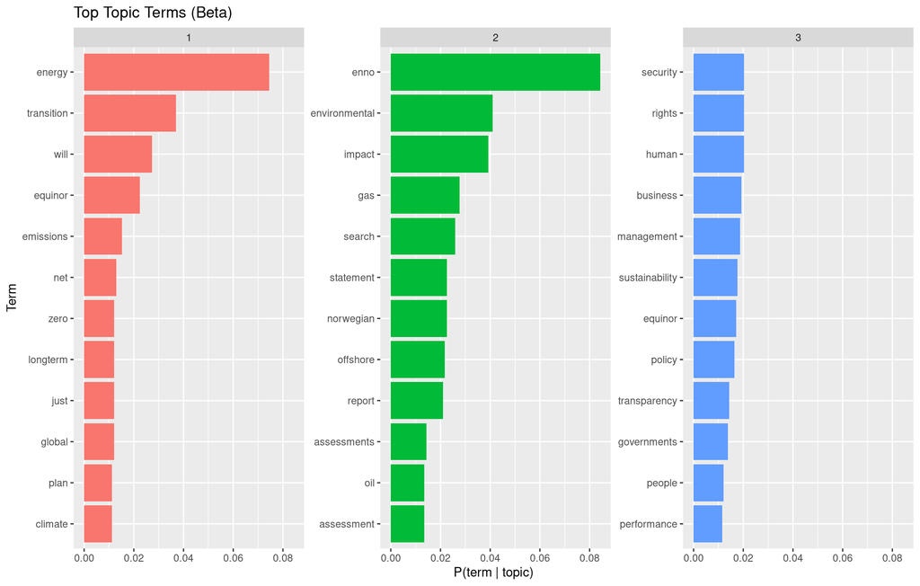

```r
top_terms_per_topic %>%
  mutate(term_plot = reorder_within(term, beta, topic)) %>%
  ggplot(aes(x = term_plot, y = beta, fill = factor(topic))) +
  geom_col(show.legend = FALSE) +
  coord_flip() +
  tidytext::scale_x_reordered() +
  facet_wrap(~topic, scales = "free_y") +
  labs(
    title = "Top Topic Terms (Beta)",
    x = "Term",
    y = "P(term | topic)"
  )
```

Interpretation: each topic is defined by a characteristic high-probability term set, which provides semantic labels for the discovered themes.

#### Top topics per document

```r
per_doc_top_topics <- gamma_tbl %>%
  group_by(doc_id) %>%
  slice_max(gamma, n = 3, with_ties = FALSE) %>%
  ungroup() %>%
  arrange(doc_id, desc(gamma))

primary_topic_per_doc <- gamma_tbl %>%
  group_by(doc_id) %>%
  slice_max(gamma, n = 1, with_ties = FALSE) %>%
  ungroup() %>%
  arrange(desc(gamma))

kable(
  per_doc_top_topics %>% mutate(gamma = round(gamma, 4)),
  caption = "Top topics per document (top 3 by gamma)"
)
```

Top topics per document (top 3 by gamma)

| document | topic | gamma | doc_id |
| --- | --- | --- | --- |
| equinor01-protecting-the-environment.txt | 2 | 0.4617 | equinor01-protecting-the-environment.txt |
| equinor01-protecting-the-environment.txt | 3 | 0.3372 | equinor01-protecting-the-environment.txt |
| equinor01-protecting-the-environment.txt | 1 | 0.2010 | equinor01-protecting-the-environment.txt |
| equinor02-health-safety-and-security.txt | 3 | 0.7624 | equinor02-health-safety-and-security.txt |
| equinor02-health-safety-and-security.txt | 1 | 0.1390 | equinor02-health-safety-and-security.txt |
| equinor02-health-safety-and-security.txt | 2 | 0.0986 | equinor02-health-safety-and-security.txt |
| equinor03-human-rights.txt | 3 | 0.7741 | equinor03-human-rights.txt |
| equinor03-human-rights.txt | 2 | 0.1439 | equinor03-human-rights.txt |
| equinor03-human-rights.txt | 1 | 0.0820 | equinor03-human-rights.txt |
| equinor04-governance-and-transparency.txt | 3 | 0.6261 | equinor04-governance-and-transparency.txt |
| equinor04-governance-and-transparency.txt | 2 | 0.1957 | equinor04-governance-and-transparency.txt |
| equinor04-governance-and-transparency.txt | 1 | 0.1783 | equinor04-governance-and-transparency.txt |
| equinor05-our-transition-ambitions.txt | 1 | 0.6927 | equinor05-our-transition-ambitions.txt |
| equinor05-our-transition-ambitions.txt | 2 | 0.1977 | equinor05-our-transition-ambitions.txt |
| equinor05-our-transition-ambitions.txt | 3 | 0.1096 | equinor05-our-transition-ambitions.txt |
| equinor06-a-just-energy-transition.txt | 1 | 0.4987 | equinor06-a-just-energy-transition.txt |
| equinor06-a-just-energy-transition.txt | 3 | 0.3656 | equinor06-a-just-energy-transition.txt |
| equinor06-a-just-energy-transition.txt | 2 | 0.1358 | equinor06-a-just-energy-transition.txt |
| equinor07-environmental-social-and-governance-esg-reporting-centre.txt | 3 | 0.4290 | equinor07-environmental-social-and-governance-esg-reporting-centre.txt |
| equinor07-environmental-social-and-governance-esg-reporting-centre.txt | 2 | 0.3612 | equinor07-environmental-social-and-governance-esg-reporting-centre.txt |
| equinor07-environmental-social-and-governance-esg-reporting-centre.txt | 1 | 0.2098 | equinor07-environmental-social-and-governance-esg-reporting-centre.txt |
| equinor08-impact-assessments.txt | 2 | 0.8417 | equinor08-impact-assessments.txt |
| equinor08-impact-assessments.txt | 1 | 0.0839 | equinor08-impact-assessments.txt |
| equinor08-impact-assessments.txt | 3 | 0.0745 | equinor08-impact-assessments.txt |
| equinor09-energy-perspectives.txt | 1 | 0.6146 | equinor09-energy-perspectives.txt |
| equinor09-energy-perspectives.txt | 2 | 0.2182 | equinor09-energy-perspectives.txt |
| equinor09-energy-perspectives.txt | 3 | 0.1672 | equinor09-energy-perspectives.txt |

```r
kable(
  primary_topic_per_doc %>% mutate(gamma = round(gamma, 4)),
  caption = "Primary topic assignment per document"
)
```

Primary topic assignment per document

| document | topic | gamma | doc_id |
| --- | --- | --- | --- |
| equinor08-impact-assessments.txt | 2 | 0.8417 | equinor08-impact-assessments.txt |
| equinor03-human-rights.txt | 3 | 0.7741 | equinor03-human-rights.txt |
| equinor02-health-safety-and-security.txt | 3 | 0.7624 | equinor02-health-safety-and-security.txt |
| equinor05-our-transition-ambitions.txt | 1 | 0.6927 | equinor05-our-transition-ambitions.txt |
| equinor04-governance-and-transparency.txt | 3 | 0.6261 | equinor04-governance-and-transparency.txt |
| equinor09-energy-perspectives.txt | 1 | 0.6146 | equinor09-energy-perspectives.txt |
| equinor06-a-just-energy-transition.txt | 1 | 0.4987 | equinor06-a-just-energy-transition.txt |
| equinor01-protecting-the-environment.txt | 2 | 0.4617 | equinor01-protecting-the-environment.txt |
| equinor07-environmental-social-and-governance-esg-reporting-centre.txt | 3 | 0.4290 | equinor07-environmental-social-and-governance-esg-reporting-centre.txt |

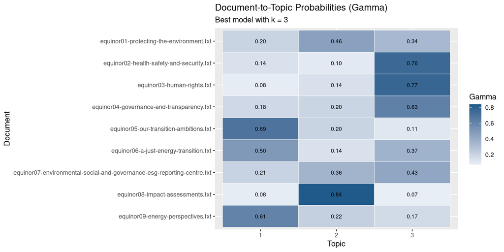

```r
gamma_tbl %>%
  ggplot(aes(x = factor(topic), y = forcats::fct_rev(doc_id), fill = gamma)) +
  geom_tile(color = "white") +
  geom_text(aes(label = sprintf("%.2f", gamma)), size = 2.8) +
  scale_fill_gradient(low = "#e8eef5", high = "#1f5a8a") +
  labs(
    title = "Document-to-Topic Probabilities (Gamma)",
    subtitle = paste0("Best model with k = ", best_k),
    x = "Topic",
    y = "Document",
    fill = "Gamma"
  )
```

Interpretation: documents typically show one dominant topic with smaller secondary mixtures, which is expected for report sections that each emphasize a main theme but share ESG vocabulary.